# MUSICA METAL = SALUD y FELICIDAD?

Maria_Alonso

2026-10-19

# MUSICA METAL = SALUD y FELICIDAD?

## Introducción

En este proyecto se quiere estudiar si existe alguna relación entre la presencia de bandas de música metal en los distintos países, la felicidad de sus habitantes y su esperanza de vida saludable.

Para realizar el análisis, se han utilizado datos de diferentes fuentes: Metal Archives, para obtener información sobre las bandas de metal; el World Happiness Report, para conocer los niveles de felicidad de cada país; el Banco Mundial, para obtener los datos de población; y la Organización Mundial de la Salud (OMS), para consultar la esperanza de vida saludable (HALE).

El trabajo se divide en tres partes. Primero, se estudia la relación entre la felicidad y la esperanza de vida saludable. Después, se analiza si existe alguna relación entre el número de bandas de metal por cada 100.000 habitantes y la felicidad. Por último, se estudia la relación entre la presencia de bandas de metal y la esperanza de vida saludable.

Para poder comparar los datos, se han unido las distintas fuentes utilizando los códigos ISO3 de los países. También se han elaborado gráficos y mapas para visualizar mejor los resultados y se han calculado diferentes coeficientes de correlación para conocer cómo se relacionan las variables.

Es importante tener en cuenta que el objetivo es estudiar si existe alguna relación entre estas variables, no demostrar que una sea la causa de la otra.

## Carga de las librerías

Para comenzar el análisis, se instalan y cargan las librerías necesarias. Estas librerías permiten importar, organizar y transformar los datos, realizar los análisis estadísticos y elaborar gráficos y mapas.

```r
#install.packages("stringi")
#install.packages("rnaturalearth")
#install.packages("rnaturalearthdata")
library(tidyverse)
library(readxl)
library(pdftools)
```

```r
library(knitr)
library(corrplot)
library(scales)
library(sf)
library(dplyr)
library(countrycode)
library(rnaturalearth)
library(rnaturalearthdata)
library(ggplot2)
```

## Importación y preparación de los datasets

Para realizar el análisis se han utilizado cuatro fuentes principales de información, que contienen datos sobre bandas de metal, población, felicidad y esperanza de vida saludable. A continuación, se describe cada una de ellas y el proceso seguido para preparar los datos.

- Encyclopaedia Metallum (The Metal Archives):

Se ha utilizado una base de datos de bandas de metal que contiene información sobre su nombre, país de origen, género musical y estado de actividad. A partir de estos datos se ha calculado el número de bandas activas o en pausa por país.

```r
# Cargar datos sobre las bandas de metal

# La ruta
ruta_metal <- "INPUT/Metal/metal_bands.csv"

if (!file.exists(ruta_metal)) {
  stop("No se ha encontrado el documento. Comprueba la ruta.")
}

metal_bandas <- read.csv(
  ruta_metal,
  na.strings = c("", "NA")
)
```

Este dataset es el que mas ha sido tratado para poder usarse bien, ya que ni se necesitan las columnas ni viene con toda la información al completo de todas las bandas. Por lo tanto, se han seleccionado solo las que si se necesitan y algunos valores se han tenido que normalizar para facilitar su tratamiento:

```r
#Columna que sirven

col_usar <- c("Band.ID", "Name", "Country", "Genre", "Status")

if (!all(col_usar %in% names(metal_bandas))){
  stop( "No están todas las columnas"
  )
}

# Crear una tabla nueva con las variables seleccionadas
# mantener el dataset original sin modificar

metal <- metal_bandas %>%
  transmute(
    id_banda = as.character(Band.ID),
    nombre = trimws(as.character(Name)),
    pais = trimws(as.character(Country)),
    genero = trimws(as.character(Genre)),
    estado = trimws(as.character(Status))
  ) %>%

  # Sustituir las cadenas vacías por valores NA

  mutate(
    pais = na_if(pais, ""),
    genero = na_if(genero, ""),
    estado = na_if(estado, "")
  )
```

Finalmente, primero se excluyen las bandas los paises que no existen y los que son internacionales o no se saben, mientras se conservan las bandas cuyo estado figura como «Active» o «On hold», también se agrupan por país. Para facilitar la unión con las demás fuentes, se asigna a cada país su correspondiente código ISO3.

```r
bandas_pais <- metal %>%

  filter(
    !is.na(pais),
    !pais %in% c("International", "Unknown"),
    estado %in% c("Active","On hold")
  ) %>%

  #Asignar a cada pais su código ISO3

  mutate(
    iso3c = countrycode(
      pais,
      origin = "country.name",
      destination = "iso3c"
    )
  ) %>%

  # Quitar los paises que no tienen un código ISO3

  filter(!is.na(iso3c)) %>%
  count(pais, iso3c, name = "bandas_func", sort = TRUE)
```

- World Development Indicators (Banco Mundial):

Se ha utilizado el indicador *Population, total* del Banco Mundial para obtener la población de cada país en 2024.

Esta información permite relativizar el número de bandas de metal según el tamaño de la población, calculando posteriormente el número de bandas por cada 100.000 habitantes. De esta manera, se facilita la comparación entre países con poblaciones muy diferentes.

```r
# La ruta
ruta_gente<- "INPUT/Gente/Gente.xls"

#Si no existe, avisar
if (!file.exists(ruta_gente)){
  stop("No se ha encontrado el documento. Comprueba la ruta.")
}

# Leerla y quitar las 3 primeras lineas que no hacen la gran cosa
gente_PIB <- readxl :: read_excel(
  ruta_gente, skip = 3
)

#view(gente_PIB)
```

```r
# crear una columna para los códigos iso3c y quitar los NA

poblacion2024 <- gente_PIB %>%
  transmute(
    pais = `Country Name`,
    iso3c = `Country Code`,
    poblacion = as.numeric(`2024`)
  ) %>%
  filter(!is.na(poblacion))

#View(poblacion2024)
```

- World Happiness Report:

Esta variable se emplea como indicador del nivel de felicidad y satisfacción vital de cada país. Para poder combinar esta información con las demás fuentes, se han obtenido los códigos ISO3 correspondientes a los países y se han eliminado los registros sin información válida para el análisis.

```r
ruta_fel<- "INPUT/Felicidad/Felicidad_datos.xls"

#Si no existe, avisar
fel_datos <- readxl :: read_excel(
  ruta_fel
)

#view(fel_datos)

fel_iso <- fel_datos %>%
  mutate(
    iso3c = countrycode(`Country name`, origin = "country.name", destination = "iso3c"))
#view(fel_iso)
```

```r
# crear una columna para los códigos iso3c, escoger la columna de "Lader score" y quitar los NA

felicidad <- fel_iso %>%
  transmute(
    iso3c = iso3c,
    pais = `Country name`,
    felicidad = as.numeric(`Ladder score`)
  ) %>%
  filter(!is.na(iso3c), !is.na(felicidad))
```

- Global Health Observatory (Organización Mundial de la Salud)

Se ha utilizado el indicador *Healthy life expectancy* (HALE), que estima el número de años que una persona puede esperar vivir con buena salud.

Para el análisis se han seleccionado los registros correspondientes al conjunto de la población, sin distinción por sexo, y se han considerado los datos comprendidos entre 2000 y 2024. Posteriormente, se ha seleccionado para cada país el último año con información disponible.

```r
ruta_hale <- "INPUT/HALE/HALE.csv"

if (!file.exists(ruta_hale)) {
  stop("No se ha encontrado el archivo HALE. Comprueba la ruta.")
}

hale_datos <- read.csv(
  ruta_hale,
  na.strings = c("", "NA"),
  check.names = FALSE
)

#view(hale_datos)
```

```r
#crear una columna para los códigos iso3c, filtrar los datos por género y año, finalmente quitar los NA

hale_paises <- hale_datos %>%
  filter(DIM_SEX == "TOTAL", as.numeric(as.character(DIM_TIME)) >= 2000,
         as.numeric(as.character(DIM_TIME)) <= 2024) %>%
  transmute(pais = GEO_NAME_SHORT, year= as.numeric(as.character(DIM_TIME)),
            hale = as.numeric(AMOUNT_N)) %>%
  mutate(
    iso3c = countrycode(pais, origin = "country.name", destination = "iso3c")
  ) %>%
  filter(!is.na(iso3c), !is.na(hale))
hale_final <- hale_paises %>%
  group_by(iso3c) %>%
  arrange(desc(year), .by_group = TRUE) %>%
  slice(1) %>%
  ungroup() %>%
  arrange(pais)
```

Adicionalmente, se ha utilizado Natural Earth como fuente de información geográfica para obtener los límites territoriales necesarios para elaborar los mapas. Esta fuente se emplea exclusivamente para la representación cartográfica.

Finalmente, los conjuntos de datos se han combinado mediante los códigos ISO3 de cada país. Esto permite identificar los países de forma homogénea entre las distintas fuentes y facilita la comparación de las variables utilizadas en el estudio.

## Objetivos

- G01: Relación entre felicidad y esperanza de vida saludable
- G02: Relación entre bandas de metal y felicidad
- G03: Relación entre bandas de metal y esperanza de vida saludable

## Primer Objetivo: Relación entre la salud y la felicidad

La salud y la felicidad son dos dimensiones fundamentales del bienestar de una población. Analizar su asociación permite explorar si los países con una mayor esperanza de vida saludable también presentan mayores niveles de felicidad.

- Preparación de datos

En primer lugar, se unen los datos de felicidad y esperanza de vida saludable mediante el código ISO3 de cada país, lo que permite trabajar con ambas variables en una misma tabla.

Posteriormente, se seleccionan los diez países con mayor puntuación de felicidad y se identifican los países europeos para realizar un análisis específico de esta región.

```r
analisis1 <- felicidad %>%
  inner_join(
    hale_final %>% select(iso3c, hale, year),
    by = "iso3c"
  )

# Seleccionar los 5 países con mayor felicidad
paises_destacados_1 <- analisis1 %>%
  slice_max(order_by = felicidad, n = 10, with_ties = FALSE) %>%
  select(pais, felicidad, hale, year)

# Identificar los paises europeos del análisis
analisis1_europa <- analisis1 %>%
  mutate(continente = countrycode(iso3c,
                                 origin = "iso3c",
                                 destination = "continent")) %>%
  filter(continente == "Europe")
```

- Mapa mundial

A continuación, se obtiene un mapa mundial y se asigna a cada país su código ISO3 para facilitar la unión con los datos del análisis.

Una vez combinadas, se representa geográficamente la esperanza de vida saludable, permitiendo visualizar su distribución entre los países incluidos en el estudio.

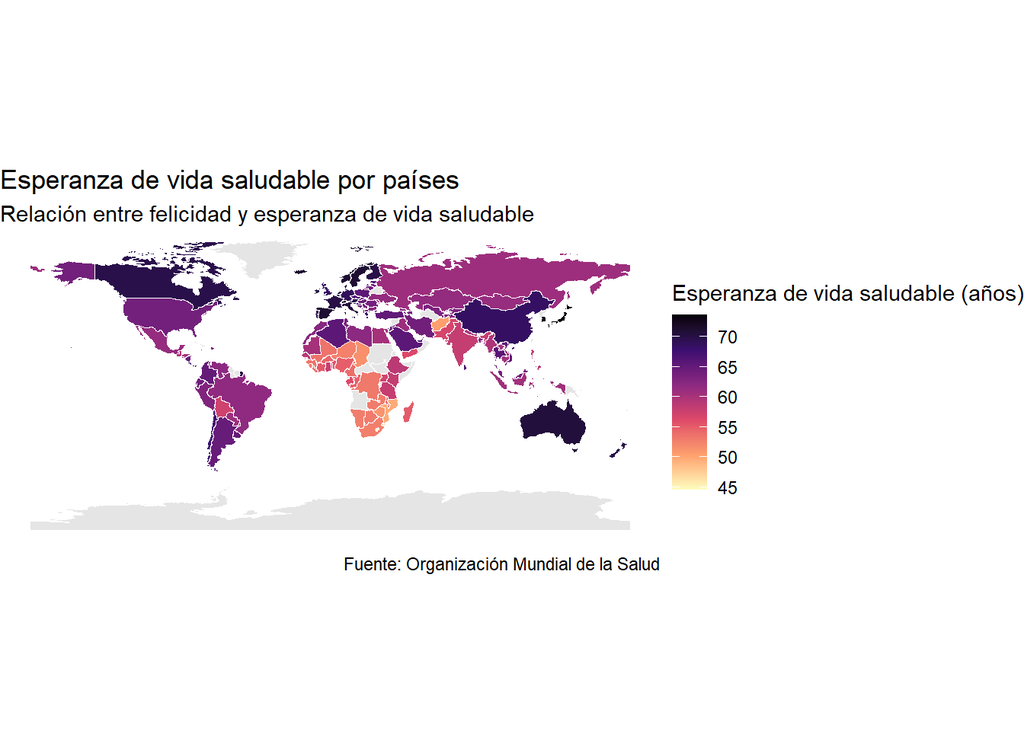

```r
# Obtener el mapa mundial

mapa_mun <- ne_countries(scale = "medium", returnclass = "sf")

# Crear códigos ISO3 automáticamente para los países del mapa

mapa_mun <- mapa_mun %>%
  mutate(
    codigo_iso = countrycode(
      admin,
      origin = "country.name",
      destination = "iso3c",
      warn = FALSE
    )
  )

# Preparar los datos del análisis 1

datos_mapa1 <- analisis1 %>%
  select(iso3c, hale, felicidad)

# Unir el mapa con los datos del análisis 1

mapa_analisis1 <- mapa_mun %>%
  left_join(datos_mapa1, by = c("codigo_iso" = "iso3c"))

# Representar la esperanza de vida saludable

mapa1 <- ggplot(mapa_analisis1) +
  geom_sf(aes(fill = hale), color = "white", linewidth = 0.1) +
  scale_fill_viridis_c(
    option = "magma",
    direction = -1,
    na.value = "grey90",
    name = "Esperanza de vida saludable (años)"
  ) +
  labs(
    title = "Esperanza de vida saludable por países",
    subtitle = "Relación entre felicidad y esperanza de vida saludable",
    caption = "Fuente: Organización Mundial de la Salud"
  ) +
  theme_void()

# Mostrar el mapa

mapa1
```

```r
# Guardar el mapa

ggsave(
  "OUTPUT/mapas/mapa1_halefelicidad.png",
  plot = mapa1,
  width = 12,
  height = 7,
  dpi = 300
)
```

- Mapa de Europa

Para facilitar la visualización de los resultados y apreciar mejor las diferencias entre países, se elabora un mapa centrado en Europa, donde se representa la esperanza de vida saludable de los países incluidos en el análisis.

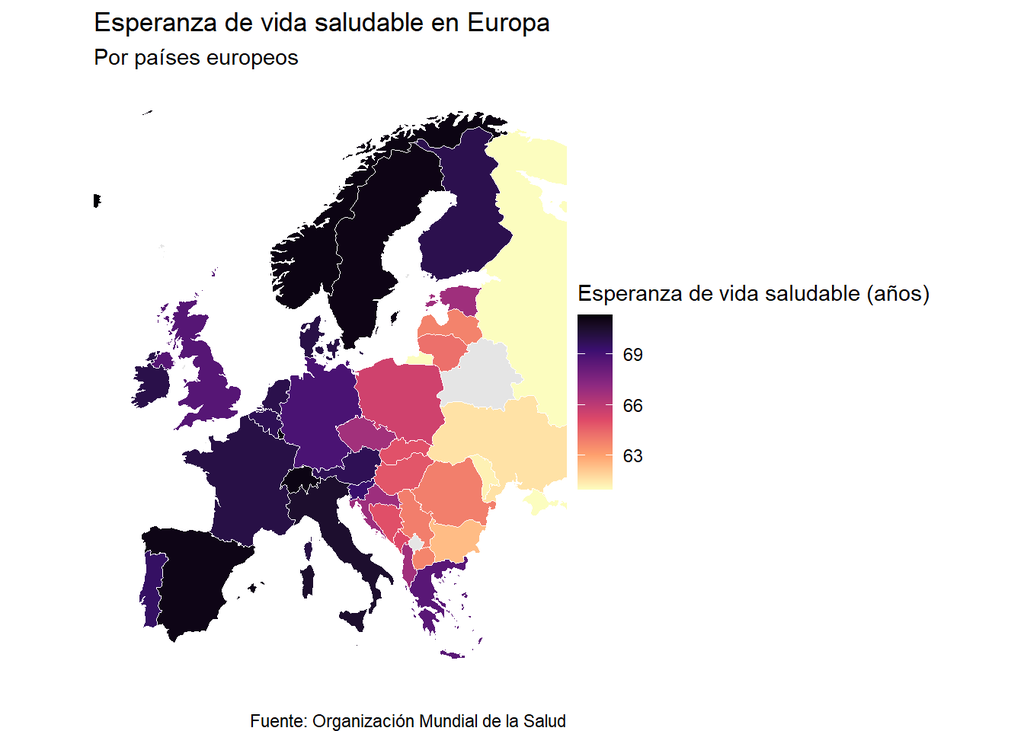

```r
# Obtener el mapa de Europa

mapa_europa <- ne_countries(
  scale = "medium",
  continent = "Europe",
  returnclass = "sf"
)

# Crear los códigos ISO3 automáticamente para los países del mapa

mapa_europa <- mapa_europa %>%
  mutate(
    codigo_iso = countrycode(
      admin,
      origin = "country.name",
      destination = "iso3c",
      warn = FALSE
    )
  )

# Preparar los datos del análisis 1 de Europa

datos_mapa1_europa <- analisis1_europa %>%
  select(iso3c, hale, felicidad)

# Unir el mapa con los datos europeos

mapa_analisis1_europa <- mapa_europa %>%
  left_join(
    datos_mapa1_europa,
    by = c("codigo_iso" = "iso3c")
  )

# Representar la esperanza de vida saludable en Europa

grafico_mapa1_europa <- ggplot(mapa_analisis1_europa) +
  geom_sf(aes(fill = hale), color = "white", linewidth = 0.2) +
  scale_fill_viridis_c(
    option = "magma",
    direction = -1,
    na.value = "grey90",
    name = "Esperanza de vida saludable (años)"
  ) +
  labs(
    title = "Esperanza de vida saludable en Europa",
    subtitle = "Por países europeos",
    caption = "Fuente: Organización Mundial de la Salud"
  ) +
  coord_sf(xlim = c(-12, 35), ylim = c(34, 72)) +
  theme_void()

# Mostrar el mapa

grafico_mapa1_europa
```

```r
# Guardar el mapa

ggsave(
  "OUTPUT/mapas/mapa1_europa.png",
  plot = grafico_mapa1_europa,
  width = 10,
  height = 7,
  dpi = 300
)
```

En el mapa se observa que la esperanza de vida saludable es más alta en Norteamérica, Oceanía, Europa y el este de Asia, con Canadá, Australia y China entre los tonos más oscuros. Estados Unidos, Rusia y buena parte de Latinoamérica se sitúan en valores intermedios. Los valores más bajos se concentran en África subsahariana y, en menor medida, en el sur de Asia, con países que quedan en torno a los 50-55 años.

- Gráfico de dispersión

A continuación, se representa gráficamente la relación entre la esperanza de vida saludable y la felicidad mediante un diagrama de dispersión. Se incluyen los países con las puntuaciones de felicidad más elevadas para facilitar su identificación en el gráfico, así como una línea de regresión que permite visualizar la tendencia general de la relación entre ambas variables.

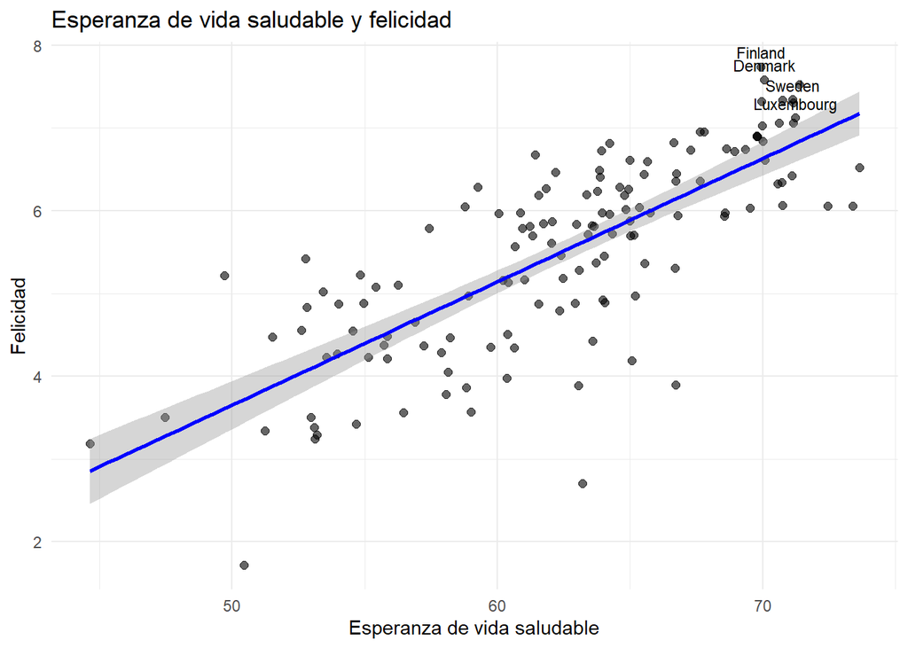

```r
grafico1 <- ggplot(analisis1, aes(x = hale, y = felicidad)) +
  geom_point(size = 2, alpha = 0.6) +
  geom_smooth(method = "lm", se = TRUE, color = "blue") +
  geom_text( data = paises_destacados_1,aes(label = pais),size = 3,vjust = -0.7, check_overlap = TRUE) +
  labs(
    title = "Esperanza de vida saludable y felicidad",
    x = "Esperanza de vida saludable",
    y = "Felicidad"
  ) +
  theme_minimal()

# Mostrar el gráfico

grafico1
```

```r
# Guardar el gráfico

ggsave(
  "OUTPUT/graficos/grafico1_hale_felicidad.png",
  plot = grafico1,
  width = 10,
  height = 6,
  dpi = 300
)
```

## Segundo Objetivo: Metal y felicidad

La música forma parte de la identidad cultural y social de una población. Analizar su relación con la felicidad permite explorar si los países con una mayor presencia de bandas de metal también presentan mayores niveles de felicidad.

- Preparar los datos

Para estudiar la relación entre la presencia de bandas de metal y la felicidad, se combinan los datos del número de bandas por país con los datos de población y felicidad. Para poder comparar países de distinto tamaño, se calcula el número de bandas de metal por cada 100.000 habitantes. De este modo, se utiliza una medida relativa en lugar del número absoluto de bandas.

```r
analisis2 <- bandas_pais %>%
  left_join(
    poblacion2024 %>%
      select(iso3c, poblacion),
    by = "iso3c"
  ) %>%
  mutate(
    bandas_100milhab = (bandas_func / poblacion) * 100000
  ) %>%
  inner_join(
    felicidad %>% select(iso3c, felicidad),
    by = "iso3c"
  )

# Seleccionar los 5 países con mayor número de bandas de metal por cada 100.000 habitantes

paises_destacados_2 <- analisis2 %>%
  slice_max(
    order_by = bandas_100milhab,
    n = 5,
    with_ties = FALSE
  ) %>%
  select(pais, bandas_func, poblacion, bandas_100milhab, felicidad)

# Identificar los países europeos del análisis

analisis2_europa <- analisis2 %>%
  mutate(continente = countrycode(iso3c,
                                 origin = "iso3c",
                                 destination = "continent")) %>%
  filter(continente == "Europe")
```

- Mapa del mundo

Para visualizar la distribución de bandas de metal entre los distintos países, se elabora un mapa mundial en el que se representa el número de bandas por cada 100.000 habitantes. Esta representación permite comparar la presencia relativa de bandas de metal entre países, teniendo en cuenta las diferencias de población.

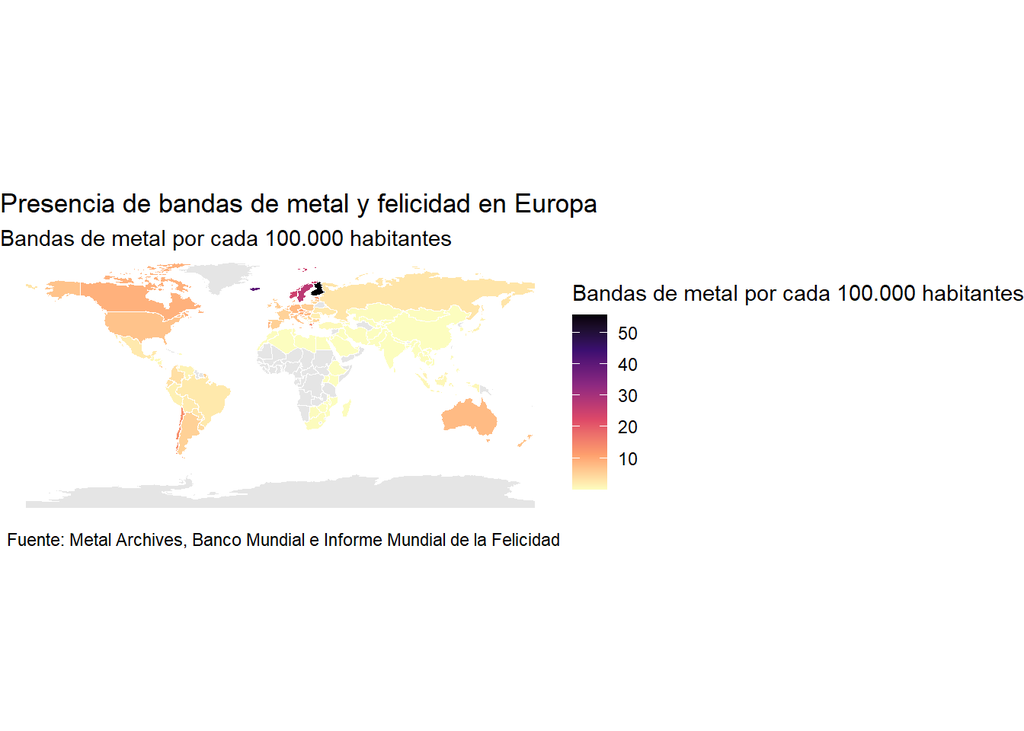

```r
# Obtener el mapa mundial

mapa_mun <- ne_countries(scale = "medium", returnclass = "sf")

#  Crear los códigos ISO3 de los países del mapa

mapa_mun <- mapa_mun %>%
  mutate(
    codigo_iso = countrycode(
      admin,
      origin = "country.name",
      destination = "iso3c",
      warn = FALSE
    )
  )

# Preparar los datos del análisis 2

datos_mapa2 <- analisis2 %>%
  select(iso3c, bandas_100milhab, felicidad)

# Unir el mapa con los datos del análisis 2

mapa_analisis2 <- mapa_mun %>%
  left_join(datos_mapa2, by = c("codigo_iso" = "iso3c"))

# Representar el número de bandas de metal por cada 100.000 habitantes

mapa2 <- ggplot(mapa_analisis2) +
  geom_sf(aes(fill = bandas_100milhab), color = "white", linewidth = 0.1) +
  scale_fill_viridis_c(
    option = "magma",
    direction = -1,
    na.value = "grey90",
    name = "Bandas de metal por cada 100.000 habitantes"
  ) +
  labs(
    title = "Presencia de bandas de metal y felicidad en Europa",
    subtitle = "Bandas de metal por cada 100.000 habitantes",
    caption = "Fuente: Metal Archives, Banco Mundial e Informe Mundial de la Felicidad"
  ) +
  theme_void()

# Mostrar el mapa

mapa2
```

```r
# Guardar el mapa

ggsave(
  "OUTPUT/mapas/mapa2_metalfelicidad.png",
  plot = mapa2,
  width = 12,
  height = 7,
  dpi = 300
)
```

- Mapa de Europa

Para facilitar la visualización de los resultados y apreciar mejor las diferencias entre países europeos, se elabora un mapa centrado en Europa, donde se representa el número de bandas de metal por cada 100.000 habitantes.

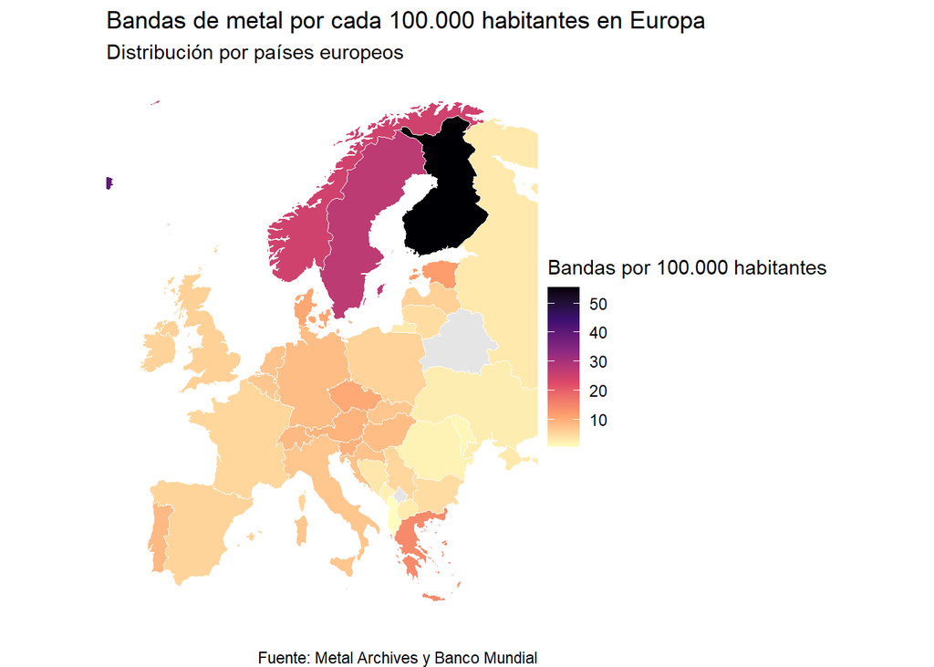

```r
# Obtener el mapa de Europa

mapa_europa <- ne_countries(
  scale = "medium",
  continent = "Europe",
  returnclass = "sf"
)

# Crear los códigos ISO3 de los países del mapa

mapa_europa <- mapa_europa %>%
  mutate(
    codigo_iso = countrycode(
      admin,
      origin = "country.name",
      destination = "iso3c",
      warn = FALSE
    )
  )

# Preparar los datos del análisis 2 de Europa

datos_mapa2_europa <- analisis2_europa %>%
  select(iso3c, bandas_100milhab, felicidad)

# Unir el mapa con los datos europeos

mapa_analisis2_europa <- mapa_europa %>%
  left_join(
    datos_mapa2_europa,
    by = c("codigo_iso" = "iso3c")
  )

# Crear el mapa

grafico_mapa2_europa <- ggplot(mapa_analisis2_europa) +
  geom_sf(aes(fill = bandas_100milhab),
          color = "white",
          linewidth = 0.2) +
  scale_fill_viridis_c(
    option = "magma",
    direction = -1,
    na.value = "grey90",
    name = "Bandas por 100.000 habitantes"
  ) +
  labs(
    title = "Bandas de metal por cada 100.000 habitantes en Europa",
    subtitle = "Distribución por países europeos",
    caption = "Fuente: Metal Archives y Banco Mundial"
  ) +
  coord_sf(xlim = c(-12, 35), ylim = c(34, 72)) +
  theme_void()

# Mostrar el mapa

grafico_mapa2_europa
```

```r
# Guardar el mapa

ggsave(
  "OUTPUT/mapas/mapa2_europa.png",
  plot = grafico_mapa2_europa,
  width = 10,
  height = 7,
  dpi = 300
)
```

- Diagrama de dispersión

A continuación, se representa gráficamente la relación entre el número de bandas de metal por cada 100.000 habitantes y la felicidad mediante un diagrama de dispersión. Se identifican los cinco países con mayor presencia relativa de bandas de metal y se incorpora una línea de regresión para visualizar la tendencia general de la relación entre ambas variables.

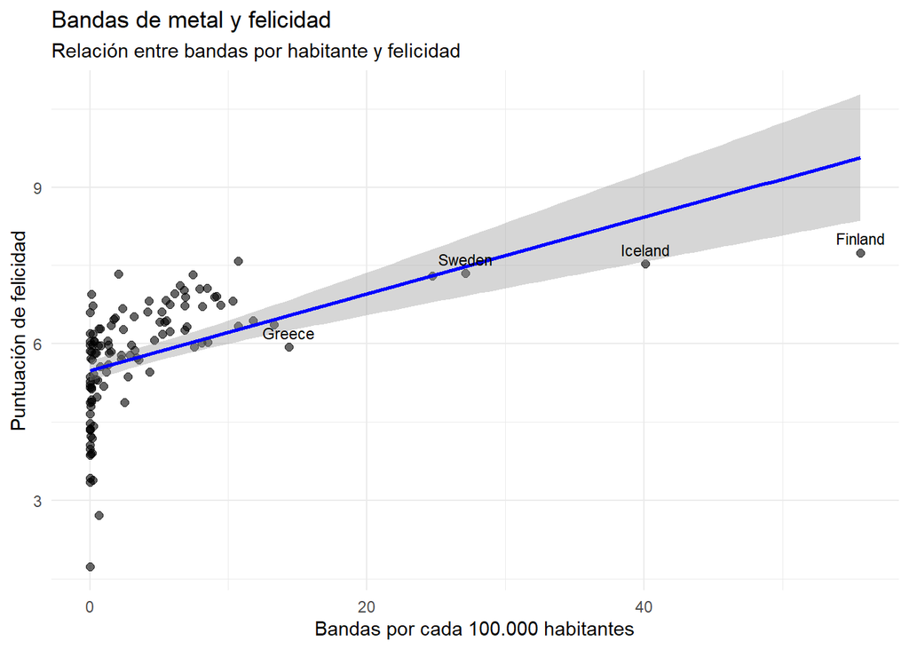

```r
grafico2 <- ggplot(analisis2,
       aes(x = bandas_100milhab, y = felicidad)) +
  geom_point(size = 2, alpha = 0.6) +
  geom_smooth(method = "lm", se = TRUE, color = "blue") +
  geom_text( data = paises_destacados_2,aes(label = pais),size = 3,vjust = -0.7, check_overlap = TRUE) +
  labs(
    title = "Bandas de metal y felicidad",
    subtitle = "Relación entre bandas por habitante y felicidad",
    x = "Bandas por cada 100.000 habitantes",
    y = "Puntuación de felicidad"
  ) +
  theme_minimal()

# Mostrar el gráfico

grafico2
```

```r
# Guardar el gráfico

ggsave(
  "OUTPUT/graficos/grafico2_metal_felicidad.png",
  plot = grafico2,
  width = 10,
  height = 6,
  dpi = 300
)
```

El diagrama muestra una relación positiva entre la presencia de bandas de metal y la felicidad, pero hay que interpretarla con cuidado. La gran mayoría de países tiene menos de 10 bandas por cada 100.000 habitantes, y dentro de ese grupo las puntuaciones de felicidad van de muy bajas a altas. La tendencia ascendente de la línea se apoya sobre todo en unos pocos países con muchas bandas por habitante, como Suecia, Islandia y Finlandia, que a la vez tienen puntuaciones de felicidad altas (entre 7 y 8 aproximadamente). La banda gris se ensancha mucho hacia la derecha, lo que indica que la relación es poco precisa en los valores altos, donde hay muy pocos países. Por eso, el gráfico muestra una asociación, pero no permite afirmar que más bandas de metal impliquen más felicidad.

## Tercer Objetivo: Metal y salud

La cultura musical puede formar parte del entorno social y cultural de una población, mientras que la esperanza de vida saludable refleja sus condiciones de salud y bienestar. Analizar su asociación permite explorar si los países con una mayor presencia de bandas de metal también presentan una mayor esperanza de vida saludable.

- Preparar los datos

Para estudiar esta relación, se combinan los datos del número de bandas de metal por país con los datos de población y esperanza de vida saludable. Al igual que en el objetivo anterior, se calcula el número de bandas por cada 100.000 habitantes para poder comparar países de distinto tamaño.

```r
analisis3 <- bandas_pais %>%
  inner_join(
    poblacion2024 %>% select(iso3c, poblacion),
    by = "iso3c"
  ) %>%
  mutate(
    bandas_100milhab = (bandas_func / poblacion) * 100000
  ) %>%
  inner_join(
    hale_final %>% select(iso3c, hale, year),
    by = "iso3c"
  )

# Seleccionar los 5 países con mayor número de bandas por cada 100.000 habitantes

paises_destacados_3 <- analisis3 %>%
  slice_max(
    order_by = bandas_100milhab,
    n = 5,
    with_ties = FALSE
  ) %>%
  select(pais, bandas_func, poblacion, bandas_100milhab, hale, year)

# Identificar los países europeos del análisis

analisis3_europa <- analisis3 %>%
  mutate(continente = countrycode(iso3c,
                                 origin = "iso3c",
                                 destination = "continent")) %>%
  filter(continente == "Europe")
```

- Mapa mundial

Para visualizar la distribución de bandas de metal entre los distintos países, se elabora un mapa mundial en el que se representa el número de bandas por cada 100.000 habitantes. Esta representación permite comparar la presencia relativa de bandas de metal entre países y la vida saludable que puedes tener en cada pais.

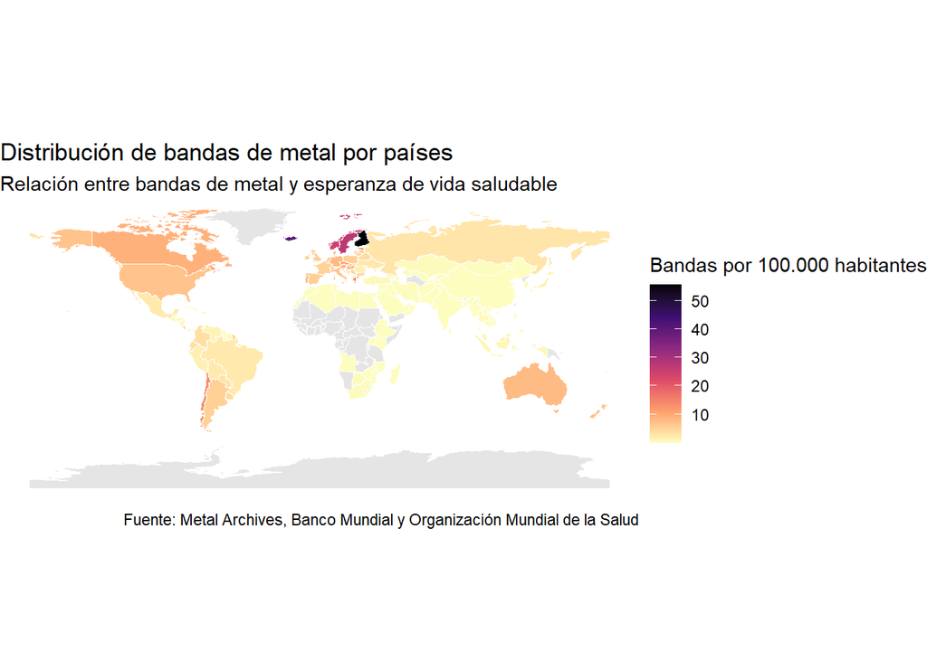

```r
# Obtener el mapa mundial
mapa_mun <- ne_countries(scale = "medium", returnclass = "sf")

# Crear códigos ISO3 automáticamente para los países del mapa
mapa_mun <- mapa_mun %>%
  mutate(
    codigo_iso = countrycode(
      admin,
      origin = "country.name",
      destination = "iso3c",
      warn = FALSE
    )
  )

# Preparar los datos del análisis 3
datos_mapa3 <- analisis3 %>%
  select(iso3c, bandas_100milhab, hale)

# Unir el mapa con los datos del análisis 3
mapa_analisis3 <- mapa_mun %>%
  left_join(datos_mapa3, by = c("codigo_iso" = "iso3c"))

# Representar el número de bandas de metal por cada 100.000 habitantes
mapa3 <- ggplot(mapa_analisis3) +
  geom_sf(aes(fill = bandas_100milhab), color = "white", linewidth = 0.1) +
  scale_fill_viridis_c(
    option = "magma",
    direction = -1,
    na.value = "grey90",
    name = "Bandas por 100.000 habitantes"
  ) +
  labs(
    title = "Distribución de bandas de metal por países",
    subtitle = "Relación entre bandas de metal y esperanza de vida saludable",
    caption = "Fuente: Metal Archives, Banco Mundial y Organización Mundial de la Salud"
  ) +
  theme_void()

#Mostrar el mapa

mapa3
```

```r
# Guardar el mapa

ggsave(
  "OUTPUT/mapas/mapa3_metalhale.png",
  plot = mapa3,
  width = 12,
  height = 7,
  dpi = 300
)
```

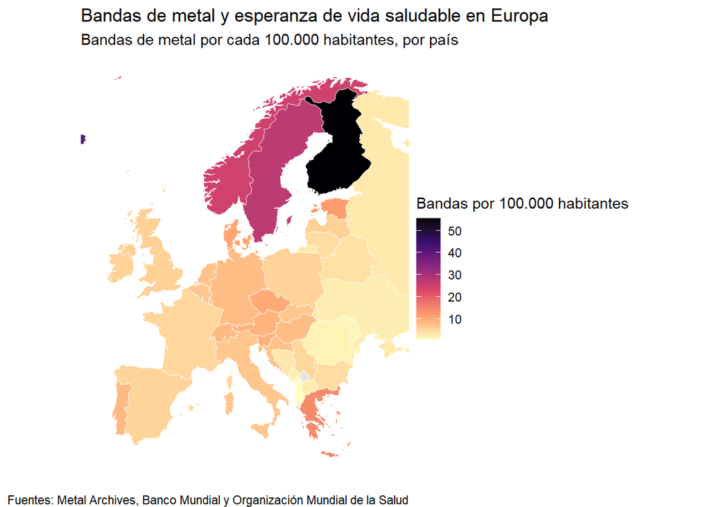

```r
# Obtener el mapa de Europa
mapa_europa <- ne_countries(
  scale = "medium",
  continent = "Europe",
  returnclass = "sf"
)

# Crear códigos ISO3 para los países del mapa
mapa_europa <- mapa_europa %>%
  mutate(
    codigo_iso = countrycode(
      admin,
      origin = "country.name",
      destination = "iso3c",
      warn = FALSE
    )
  )

# Preparar los datos del análisis 3 de Europa
datos_mapa3_europa <- analisis3_europa %>%
  select(iso3c, bandas_100milhab, hale)

# Unir el mapa con los datos europeos
mapa_analisis3_europa <- mapa_europa %>%
  left_join(
    datos_mapa3_europa,
    by = c("codigo_iso" = "iso3c")
  )

# Crear el mapa
grafico_mapa3_europa <- ggplot(mapa_analisis3_europa) +
  geom_sf(
    aes(fill = bandas_100milhab),
    color = "white",
    linewidth = 0.2
  ) +
   scale_fill_viridis_c(
    option = "magma",
    direction = -1,
    na.value = "grey90",
    name = "Bandas por 100.000 habitantes"
  )  +
  labs(
    title = "Bandas de metal y esperanza de vida saludable en Europa",
    subtitle = "Bandas de metal por cada 100.000 habitantes, por país",
    caption = "Fuentes: Metal Archives, Banco Mundial y Organización Mundial de la Salud"
  ) +
  coord_sf(xlim = c(-12, 35), ylim = c(34, 72)) +
  theme_void()

# Mostrar el mapa
grafico_mapa3_europa
```

```r
# Guardar el mapa
ggsave(
  "OUTPUT/mapas/mapa3_europa.png",
  plot = grafico_mapa3_europa,
  width = 10,
  height = 7,
  dpi = 300
)
```

En el mapa se observa que la presencia relativa de bandas de metal se concentra en el norte de Europa, con Finlandia muy por encima del resto (más de 50 bandas por cada 100.000 habitantes) y otros países nórdicos como Suecia y Noruega con valores intermedios. En el resto del mundo los valores son bajos o no hay datos. Al compararlo con el primer mapa, los países con más bandas de metal (Finlandia, Suecia, Noruega) tienen una esperanza de vida saludable alta, pero lo mismo ocurre con muchos países donde apenas hay bandas, como Canadá, Australia o Japón.

- Gráfico de dispersión

A continuación, se representa gráficamente la relación entre el número de bandas de metal por cada 100.000 habitantes y la esperanza de vida saludable mediante un diagrama de dispersión. Se identifican los cinco países con mayor presencia relativa de bandas de metal y se incorpora una línea de regresión para visualizar la tendencia general de la relación entre ambas variables.

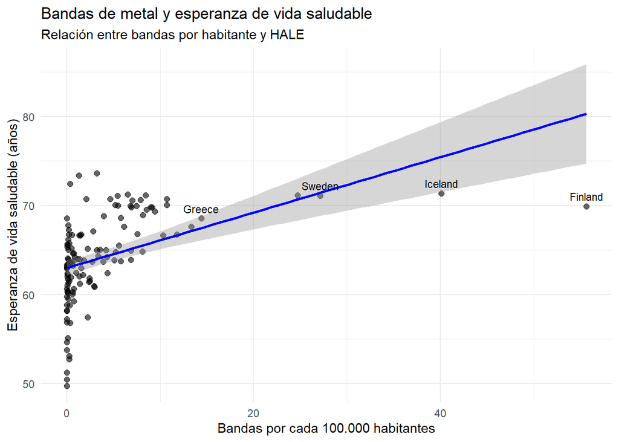

```r
grafico3 <- ggplot(analisis3, aes(x = bandas_100milhab, y = hale)) +
  geom_point(size = 2, alpha = 0.6) +
  geom_smooth(method = "lm", se = TRUE, color = "blue") +
  geom_text(
    data = paises_destacados_3, aes(label = pais), size = 3, vjust = -0.7, check_overlap = TRUE
  ) +
  labs(
    title = "Bandas de metal y esperanza de vida saludable",
    subtitle = "Relación entre bandas por habitante y HALE",
    x = "Bandas por cada 100.000 habitantes",
    y = "Esperanza de vida saludable (años)"
  ) +
  theme_minimal()

# Mostrar el gráfico

grafico3
```

```r
# Guardar el gráfico

ggsave(
  "OUTPUT/graficos/grafico3_metal_hale.png",
  plot = grafico3,
  width = 10,
  height = 6,
  dpi = 300
)
```

## Tabla de comparación de los resultados estadísticos

Para comparar los resultados obtenidos en los tres objetivos, se elabora una tabla conjunta con los coeficientes de correlación de Spearman, Kendall y Pearson.

Esta comparación permite observar la intensidad y la dirección de la asociación entre las variables de cada objetivo, así como el número de países incluidos y la significación estadística de los resultados.

```r
# Crear una función para calcular los coeficientes de correlación y los valores p de cada relación

relevancia <- function(datos, x, y, pregunta){

  # Tipos de métodos estadísticos

  tipos <- c("spearman", "kendall", "pearson")

  # Calcular las correlaciones para cada uno de los métodos

  resultados <- lapply(tipos, function(tipo){
    prueba <- cor.test(
      datos[[x]],
      datos[[y]],
      method = tipo,
      exact = FALSE
    )

    # Guardar los resultados de cada método estadístico

    tibble(
      pregunta = pregunta,
      tipo = tipo,
      casos = sum(complete.cases(datos[[x]], datos[[y]])),
      coeficiente = unname(prueba$estimate),
      p_valor = prueba$p.value
    )
  })

  bind_rows(resultados)
}

# Calcular las correlaciones correspondientes a los tres objetivos

tabla_estadistica <- bind_rows(

  # Primer objetivo

  relevancia(
    analisis1, "hale", "felicidad",
    "HALE y felicidad"
  ),

  # Segundo objetivo

  relevancia(
    analisis2, "bandas_100milhab", "felicidad",
    "Bandas de metal y felicidad"
  ),

  # Tercer objetivo

  relevancia(
    analisis3, "bandas_100milhab", "hale",
    "Bandas de metal y HALE"
  )
)
```

```r
tabla_estadistica %>%
  mutate(
    coeficiente = round(coeficiente, 3),
    p_valor = signif(p_valor, 3),
  ) %>%
  knitr::kable(
    caption = "Resultados de los contrastes estadísticos por pregunta"
  )
```

Resultados de los contrastes estadísticos por pregunta

| pregunta | tipo | casos | coeficiente | p_valor |
| --- | --- | --- | --- | --- |
| HALE y felicidad | spearman | 140 | 0.787 | 0e+00 |
| HALE y felicidad | kendall | 140 | 0.590 | 0e+00 |
| HALE y felicidad | pearson | 140 | 0.768 | 0e+00 |
| Bandas de metal y felicidad | spearman | 115 | 0.743 | 0e+00 |
| Bandas de metal y felicidad | kendall | 115 | 0.554 | 0e+00 |
| Bandas de metal y felicidad | pearson | 115 | 0.507 | 0e+00 |
| Bandas de metal y HALE | spearman | 129 | 0.671 | 0e+00 |
| Bandas de metal y HALE | kendall | 129 | 0.481 | 0e+00 |
| Bandas de metal y HALE | pearson | 129 | 0.457 | 1e-07 |

## Conclusiones

En este trabajo se ha estudiado si existe alguna relación entre la esperanza de vida saludable, la felicidad y la presencia de bandas de metal en los distintos países.

Los mapas permiten ver cómo se distribuye cada variable en el mundo, y los diagramas de dispersión muestran la relación entre ellas. En los tres gráficos la tendencia es positiva: cuando una de las variables presenta valores más altos, la otra también tiende a tenerlos, aunque en los dos gráficos de bandas de metal la relación no es claramente lineal.

La relación más fuerte se encuentra entre la esperanza de vida saludable y la felicidad, con un coeficiente de Spearman de 0,787. En el gráfico, los puntos se agrupan de forma bastante clara alrededor de la línea, lo que indica que los países donde se vive más años con buena salud suelen tener también puntuaciones de felicidad más altas.

En segundo lugar, aparece la relación entre el número de bandas de metal por cada 100.000 habitantes y la felicidad, con un valor de 0,743. La mayoría de países tiene menos de 10 bandas por cada 100.000 habitantes, y la tendencia ascendente se apoya sobre todo en unos pocos países nórdicos, como Finlandia, Islandia y Suecia, que tienen muchas bandas y puntuaciones de felicidad altas.

Por último, la relación entre las bandas de metal y la esperanza de vida saludable tiene un coeficiente de 0,671. Es la más baja de las tres: aunque la asociación es positiva, entre los países con pocas bandas la esperanza de vida saludable varía mucho, y los puntos aparecen más dispersos alrededor de la línea.

En los tres casos, los valores p son inferiores a 0,001, por lo que las relaciones encontradas son estadísticamente significativas.